# Lab 5 - EDA and plotting with R

##### Inferential Plots

Q1. Recreate the last figure in the demo (the plots with error bars) and read the papers on canvas. Use those papers and the equations for SD, SE, and CI to answer the following:

Now make the plots to compare differences among SD, SE, and CI

```r
# make components accessible to the search path
#attach(hsum)
load("P:/My Documents/BDA_Spring2018/hsum.Rda")
# we'll make 3 plots - SD, SE, and CI
par(mfrow=c(1,3))
# plot standard deviation bars for description
yax<-range(c(hsum$height-hsum$sd,hsum$height+hsum$sd))
title<-expression("Mean Height "%+-%" SD")
par(mar=c(3,4,2,1))
stripchart(hsum$height~hsum$sex,vertical=T,xlim=c(0.5,2.5),ylim=yax,
           pch=19,xlab="",ylab="Height (in)",main=title)
arrows(c(1,2),hsum$height-hsum$sd,c(1,2),hsum$height+hsum$sd,length=0.05,angle=90,code=3)
```

```r
# plot standard error bars for inference
par(mar=c(3,1,2,1))
#yax<-range(c(height-se,height+se))
title<-expression("Mean Height "%+-%" SE")
stripchart(hsum$height~hsum$sex,vertical=T,xlim=c(0.5,2.5),ylim=yax,
           pch=19,xlab="",ylab="",yaxt="n",main=title)
```

```r
arrows(c(1,2),hsum$height-hsum$se,c(1,2),hsum$height+hsum$se,length=0.05,angle=90,code=3)
# plot 95% CI for inference
par(mar=c(3,1,2,1))
```

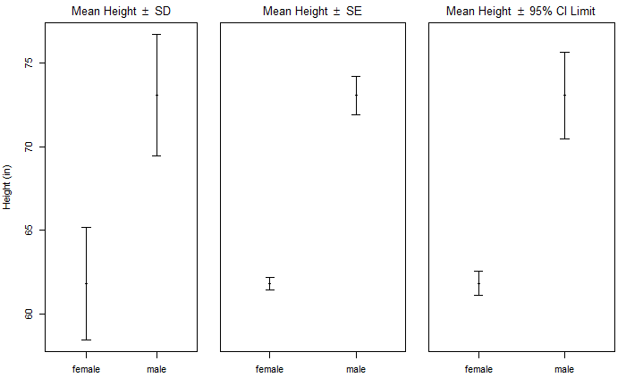

```r
#yax<-range(c(height-ci,height+ci))
title<-expression("Mean Height "%+-%" 95% CI Limit")
stripchart(hsum$height~hsum$sex,vertical=T,xlim=c(0.5,2.5),ylim=yax,
           pch=19,xlab="",ylab="",yaxt="n",main=title)
arrows(c(1,2),hsum$height-hsum$ci,c(1,2),hsum$height+hsum$ci,length=0.05,angle=90,code=3)
```

1. How do the error bar types compare to each other, and how do they depend on sample size?
- The first, standard deviation, is the variance of the data. The second, standard error, shows the variance in the estimate of the summary statisitc, the sample mean. The final plot, the confidence interval, shows the range in which would hold the sample mean 95% of the time. If the data is normally distributed, the standard deviation would be smaller as the density of data would increase near the sample mean with a larger sample size. The standard error is based on the sample size so an increase in sample size will decrease the standard error. The confidence interval will follow the reduction in variance in calculating the summary statistic and shrink as the sample size increases.
2. When would you use standard deviations for errors bars?
- I would use the standard deviations if I were describing the sample data.
3. When would you use standard errors for errors bars?
- I would use standard errors as error bars around a summary statistic to show how much error when calculating the summary statistic.
4. When would you use confidence intervals for errors bars?
- I would use a confience interval to show how much variation is expected in the summary statistic. It would show the values range within which the summary statistic would be expected to fall in that particular percent of the time.

##### Practice with plots

Q2. Modify the code in the demo that shows how to add marginal histograms to a scatterplot as follows:

1. show the bivariate distribution of father and son heights

```r
data(father.son, package = "UsingR")

plot(father.son$fheight,father.son$sheight,
     xlab="Father height", ylab="Son Height")
```

[output not shown]

2. use the lines() function to add density curve histograms to the margins (rather than the binned histograms shown in the demo)

```r
op <- par(no.readonly = TRUE)
xhist <- hist(father.son$fheight, plot = FALSE) # define histogram for x variable
yhist <- hist(father.son$sheight, plot = FALSE) # define for the y variable
top <- max(c(xhist$counts, yhist$counts))
nf <- layout(matrix(c(2,0,1,3),2,2,byrow = TRUE),
             width=c(6,1), height=c(1,4), TRUE)
par(mar = c(4,4,1,1)) # set margins for first plot
plot(father.son$fheight, father.son$sheight, xlab=expression(italic("Father Height (inch)")), pch=16,
     ylab=expression(italic("Son Height (inch)")))
par(mar = c(0,4,1,1)) # set top plot margins
plot(xhist$density, type='n', axes=FALSE, ylab="", xlab="")
lines(xhist$density,main="",ylab="",xlab="",
      ylim=c(0,150))
par(mar = c(4,0,1,1)) # set side plot margins
# sideways histograms are trickier
# use hist output in barplot, remove space between bars (space=0)
plot(yhist$density, axes = FALSE, type='n', xlim=c(0, max(yhist$counts)),
     ylim = c(range(yhist$breaks)), ylab="",xlab="")
lines(yhist$density, main="", ylab="",
     xlab="")
par(op)
```

[output not shown]

3. make sure the labels in your new plot are correct

##### QQ plots and tests

Q3. Use the father height data to answer the following questions

1. Reference the plot you made in Q1 and decide whether you think the data are normally distributed. Explain your reasoning.
2. Generate a QQ plot for the father height data and decide whether you think the data are normally distributed. Explain your reasoning

```r
scatterplotMatrix(~fheight+sheight,
                 diagonal = "qqplot",
                 data=father.son,
                 reg.line=FALSE,
                 smoother="")

ks.test(father.son$fheight, father.son$sheight)
```

[output not shown]

3. Use a KS goodness of fit test to a normal distribution to decide whether the father height data are normally distributed. Explain your reasoning.

```r
ks.test(father.son$fheight, pnorm)
```

[output not shown]

4. Reconcile your decisions and write a short paragraph explaining how you might use your results above to determine whether your data meet the assumption of normality. Feel free to modify the plotting parameters and to show the data using different types of plots to help explain your reasoning.
5. If you decided that the data are not normally distributed, how might you summarize these data in a paper?